# HW6

Julieta Tarkhanyan

April 28, 2019

*You are required to submit both Markdown and PDF files. Data set (Spam E-mail Data) relevant for this assignment can be found in the R package “DAAG”.*

Problem 1 (2 pt.)

Consider the training examples shown in the table for a binary classification problem:

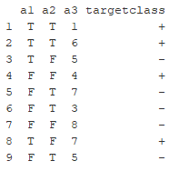

1. What is the best split (between a1 and a2) according to the classification error rate? Show calculations in R.
2. What is the best split (between a1 and a2) according to the Gini index? Show calculations in R. Which attribute would the decision tree algorithm choose? Why?
3. Why does not entropy start with 0?
4. Why DT is called a greedy algorithm?
5. The best split between a1 and a2 is a1, because it has 0.2 classification error rate
6. The best split between a1 and a2 according to Gini index is a1, because it’s value (0.34) is lower then a2’s gini index (0.49). The decision tree agorithm would choose a1 as attribute because it has the lowest gini index and class. error rate.
7. DT is called a greedy algorithm because after every split we apply the same techique to obtained smaller dataset

```r
a1 <- c(1,1,1,0,0,0,0,1,0)
a2 <- c(1,1,0,0,1,1,0,0,1)
targetclass <- c("+", "+", "-", "+", "-", "-", "-", "+", "-")

a <- data.frame(a1,a2, targetclass)
a
```

| a1 | a2 | targetclass |
| --- | --- | --- |
| 1 | 1 | + |
| 1 | 1 | + |
| 1 | 0 | - |
| 0 | 0 | + |
| 0 | 1 | - |
| 0 | 1 | - |
| 0 | 0 | - |
| 1 | 0 | + |
| 0 | 1 | - |

```r
table1 <- table(targetclass, a1)
table1
```

```
##            a1
## targetclass 0 1
##           - 4 1
##           + 1 3
```

```r
#class. error rate for a1
a1_0sum <- sum(table1[, 1])/sum(table1)
a1_1sum <- sum(table1[, 2])/sum(table1)


a1_0 <- 1 - max(table1[1,1]/(sum(table1[, 1])), table1[2,1]/(sum(table1[, 1])))
a1_0
```

```
## [1] 0.2
```

```r
a1_1 <- 1 - max(table1[1,2]/(sum(table1[, 2])), table1[2,2]/(sum(table1[, 2])))
a1_1
```

```
## [1] 0.25
```

```r
weighted_rate_a1 <- a1_0sum * a1_0 + a1_1sum * a1_1

weighted_rate_a1
```

```
## [1] 0.2222222
```

```r
#class. error rate for a2

table2 <- table(targetclass, a2)
table2
```

```
##            a2
## targetclass 0 1
##           - 2 3
##           + 2 2
```

```r
a2_0sum <- sum(table2[, 1]) / sum(table2)
a2_1sum <- sum(table2[, 2]) / sum(table2)

a2_0 <- 1 - max(table2[1,1]/(sum(table2[, 1])), table2[2,1]/(sum(table2[, 1])))
a2_0
```

```
## [1] 0.5
```

```r
a2_1 <- 1 - max(table2[1,2]/(sum(table2[, 2])), table2[2,2]/(sum(table2[, 2])))
a2_1
```

```
## [1] 0.4
```

```r
weighted_rate_a2 <- a2_0sum * a2_0 + a2_1sum * a2_1

weighted_rate_a2
```

```
## [1] 0.4444444
```

```r
#Gini index for a1
a1_0weight1 <- table1[1,1]/sum(table1[, 1])
a1_0weight2 <- table1[2,1]/sum(table1[, 1])
a1_1weight1 <- table1[1,2]/sum(table1[, 2])
a1_1weight2 <- table1[2,2]/sum(table1[, 2])
a1_0_sum <- sum(table1[, 1]) / sum(table1)
a1_1_sum <- sum(table1[, 2]) / sum(table1)

gini_a1_0 <- 1 - a1_0weight1 ^ 2 - a1_0weight2 ^ 2
gini_a1_0
```

```
## [1] 0.32
```

```r
gini_a1_1 <- 1 - a1_1weight1 ^ 2 - a1_1weight2 ^ 2
gini_a1_1
```

```
## [1] 0.375
```

```r
weighted_gini_a1 <- gini_a1_0 * a1_0_sum + gini_a1_1 * a1_1_sum
weighted_gini_a1
```

```
## [1] 0.3444444
```

```r
# gini index for a2
a2_0weight1 <- table2[1,1]/sum(table2[, 1])
a2_0weight2 <- table2[2,1]/sum(table2[, 1])
a2_1weight1 <- table2[1,2]/sum(table2[, 2])
a2_1weight2 <- table2[2,2]/sum(table2[, 2])
a2_0_sum <- sum(table2[, 1]) / sum(table2)
a2_1_sum <- sum(table2[, 2]) / sum(table2)

gini_a2_0 <- 1 - a2_0weight1 ^ 2 - a2_0weight2 ^ 2
gini_a2_0
```

```
## [1] 0.5
```

```r
gini_a2_1 <- 1 - a2_1weight1 ^ 2 - a2_1weight2 ^ 2
gini_a2_1
```

```
## [1] 0.48
```

```r
weighted_gini_a2 <- gini_a2_0 * a2_0_sum + gini_a2_1 * a2_1_sum
weighted_gini_a2
```

```
## [1] 0.4888889
```

Problem 2 (2 pt.)

1. Suppose the sysadmin wants to understand and predict the process of recognizing the emails as spam for new e-mails which make up 10% of your initial data. Use the full decision tree algorithm to solve this task. Show your tree and interpret the results.
2. How many observations have your smallest node? Set the minimum number of observations in any terminal node 25% of the number of your initial data. Show the tree. Why do we need the arguments minbucket and minsplit?
3. Which are the advantages and disadvantages (at least 2 of each) of the DT algorithm?
4. Here the root node is bang, which is the number of occurrences of the ! symbol. If it is less then 0.08 than in then next step it checks if dollar is less then 0.088 and decide spam or not. In the other hand if bang is greater then 0.08 tree provides more levels to check to determine whether the email is spam or not.
5. minbucket and minsplit control the size of the tree and it hepls to prevent from complicated trees
6. advanatges are easy to understand, can handle NA, works quickly on large datasets, works on both umerical and categorical data. disadvantages are large trees can be hard to interprete, probability of overfitting is high

```r
spam7
```

|  | crl.tot | dollar | bang | money | n000 | make | yesno |
| --- | --- | --- | --- | --- | --- | --- | --- |
| 1 | 278 | 0.000 | 0.778 | 0.00 | 0.00 | 0.00 | y |
| 2 | 1028 | 0.180 | 0.372 | 0.43 | 0.43 | 0.21 | y |
| 3 | 2259 | 0.184 | 0.276 | 0.06 | 1.16 | 0.06 | y |
| 4 | 191 | 0.000 | 0.137 | 0.00 | 0.00 | 0.00 | y |
| 5 | 191 | 0.000 | 0.135 | 0.00 | 0.00 | 0.00 | y |
| 6 | 54 | 0.000 | 0.000 | 0.00 | 0.00 | 0.00 | y |
| 7 | 112 | 0.054 | 0.164 | 0.00 | 0.00 | 0.00 | y |
| 8 | 49 | 0.000 | 0.000 | 0.00 | 0.00 | 0.00 | y |
| 9 | 1257 | 0.203 | 0.181 | 0.15 | 0.00 | 0.15 | y |
| 10 | 749 | 0.081 | 0.244 | 0.00 | 0.19 | 0.06 | y |

[output cut: 4591 more lines]

```r
levels(spam7$yesno) <- c(0, 1)

set.seed(123)
index_train <- createDataPartition(spam7$crl.tot, p = 0.9, list = F)
dim(spam7)
```

```
## [1] 4601    7
```

```r
spam_train <- spam7[index_train,]
spam_test <- spam7[-index_train,]


model_tree <- rpart(yesno ~., data = spam_train, method = "class")
model_tree
```

```
## n= 4143
##
## node), split, n, loss, yval, (yprob)
##       * denotes terminal node
##
##   1) root 4143 1633 0 (0.60584118 0.39415882)
##     2) bang< 0.0795 2395  370 0 (0.84551148 0.15448852)
##       4) dollar< 0.0875 2200  229 0 (0.89590909 0.10409091) *
##       5) dollar>=0.0875 195   54 1 (0.27692308 0.72307692) *
##     3) bang>=0.0795 1748  485 1 (0.27745995 0.72254005)
##       6) dollar< 0.0065 897  448 0 (0.50055741 0.49944259)
##        12) crl.tot< 69.5 419  120 0 (0.71360382 0.28639618) *
##        13) crl.tot>=69.5 478  150 1 (0.31380753 0.68619247)
##          26) bang< 0.4145 273  134 1 (0.49084249 0.50915751)
##            52) money< 0.095 229   98 0 (0.57205240 0.42794760)
##             104) bang< 0.1955 126   38 0 (0.69841270 0.30158730) *
##             105) bang>=0.1955 103   43 1 (0.41747573 0.58252427) *
##            53) money>=0.095 44    3 1 (0.06818182 0.93181818) *
##          27) bang>=0.4145 205   16 1 (0.07804878 0.92195122) *
##       7) dollar>=0.0065 851   36 1 (0.04230317 0.95769683) *
```

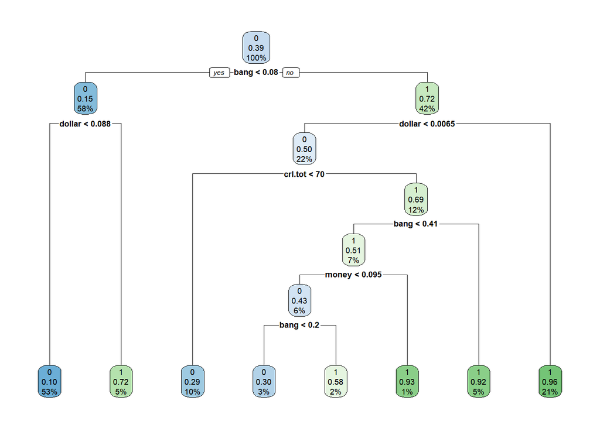

```r
rpart.plot(model_tree)
```

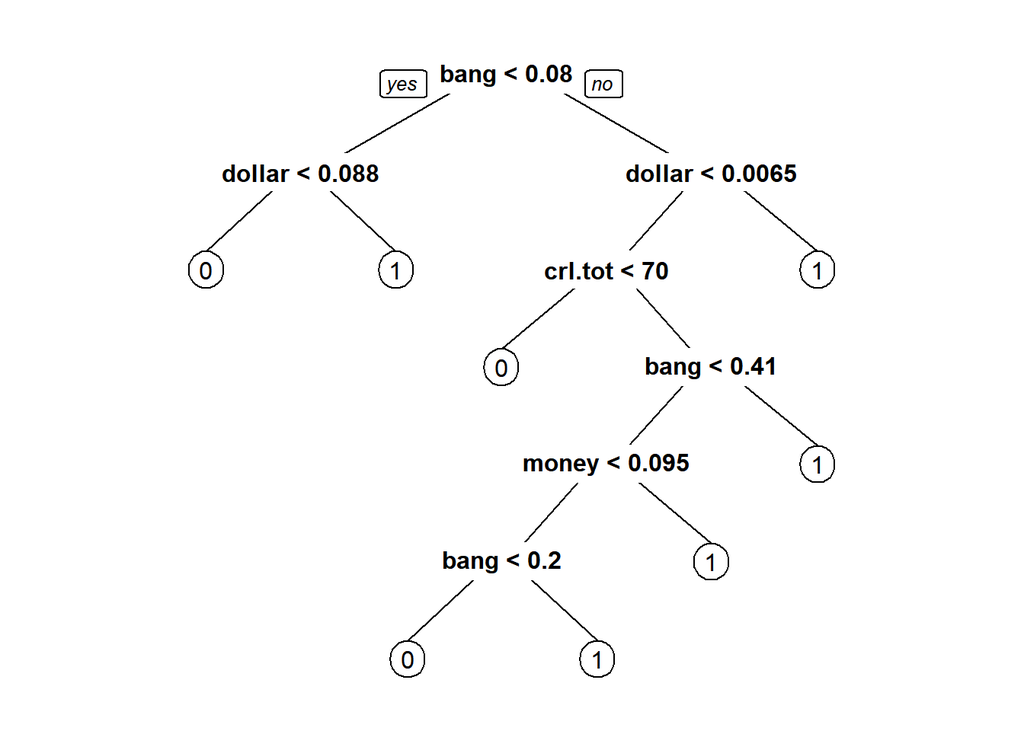

```r
prp(model_tree)
```

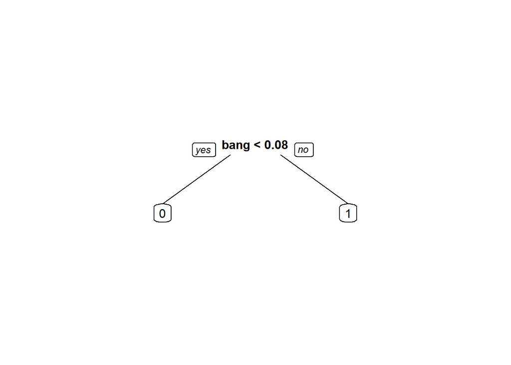

```r
model_tree1 <- rpart(yesno ~., data = spam_train, method = "class", control = rpart.control(minbucket = nrow(spam7) * 0.25))
prp(model_tree1)
```

Problem 3 (3 pt.)

1. Make predictions based on both models.
2. Compare the models using the function confusionMatrix() and their results, ROC curve, and AUC. Which does perform better? Why?
3. What is the difference between regression and classification trees (in terms of the loss function, prediction, and type of dependent variable)?
4. In terms of accuracy first model provides better results, also ROC Curve is more accurate and AUC is greater in the case of 1st model.
5. Regression trees are used when response variable is numeric or continous, thus they are used to solve prediction tasks. Classification trees are used when we need to classify the dataset into classes of response variable.There are also difference in algorithm. In regression trees target variable hasn’t classes which means we fit model to the target variable. In each split sum of squared errors is calculated and with the lowest SSE choosed as first node. This procedure is continued recursively. In classification trees algorithm works on dataset homogeneisly.

```r
library(ROCR)
pred1 <- predict(model_tree, spam_test, type = "class")
table_pred <- confusionMatrix(spam_test$yesno, pred1)
table_pred
```

```
## Confusion Matrix and Statistics
##
##           Reference
## Prediction   0   1
##          0 253  25
##          1  47 133
##
##                Accuracy : 0.8428
##                  95% CI : (0.8062, 0.8749)
##     No Information Rate : 0.655
##     P-Value [Acc > NIR] : < 2e-16
##
##                   Kappa : 0.6632
##
##  Mcnemar's Test P-Value : 0.01333
##
##             Sensitivity : 0.8433
##             Specificity : 0.8418
##          Pos Pred Value : 0.9101
##          Neg Pred Value : 0.7389
##              Prevalence : 0.6550
##          Detection Rate : 0.5524
##    Detection Prevalence : 0.6070
##       Balanced Accuracy : 0.8426
##
##        'Positive' Class : 0
##
```

```r
pred_roc <- predict(model_tree, spam_test, type = "prob")
head(pred_roc)
```

```
##             0         1
## 4  0.69841270 0.3015873
## 7  0.04230317 0.9576968
## 12 0.07804878 0.9219512
## 28 0.71360382 0.2863962
## 34 0.27692308 0.7230769
## 37 0.71360382 0.2863962
```

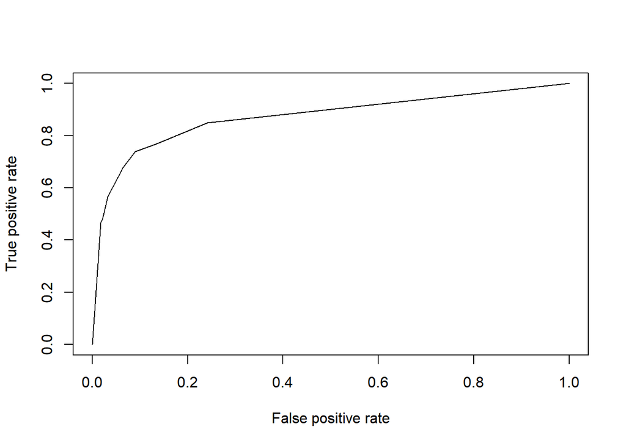

```r
pred_test <- prediction(pred_roc[,2], spam_test$yesno)
ROC1 <- performance(pred_test, "tpr", "fpr")
plot(ROC1)
```

```r
performance(pred_test,"auc")@y.values
```

```
## [[1]]
## [1] 0.8713429
```

```r
pred2 <- predict(model_tree1, spam_test, type = "class")
table_pred2 <- confusionMatrix(spam_test$yesno, pred2)
table_pred2
```

```
## Confusion Matrix and Statistics
##
##           Reference
## Prediction   0   1
##          0 220  58
##          1  47 133
##
##                Accuracy : 0.7707
##                  95% CI : (0.7295, 0.8085)
##     No Information Rate : 0.583
##     P-Value [Acc > NIR] : <2e-16
##
##                   Kappa : 0.5246
##
##  Mcnemar's Test P-Value : 0.3291
##
##             Sensitivity : 0.8240
##             Specificity : 0.6963
##          Pos Pred Value : 0.7914
##          Neg Pred Value : 0.7389
##              Prevalence : 0.5830
##          Detection Rate : 0.4803
##    Detection Prevalence : 0.6070
##       Balanced Accuracy : 0.7602
##
##        'Positive' Class : 0
##
```

```r
pred_roc1 <- predict(model_tree1, spam_test, type = "prob")
head(pred_roc1)
```

```
##            0         1
## 4  0.2774600 0.7225400
## 7  0.2774600 0.7225400
## 12 0.2774600 0.7225400
## 28 0.2774600 0.7225400
## 34 0.8455115 0.1544885
## 37 0.2774600 0.7225400
```

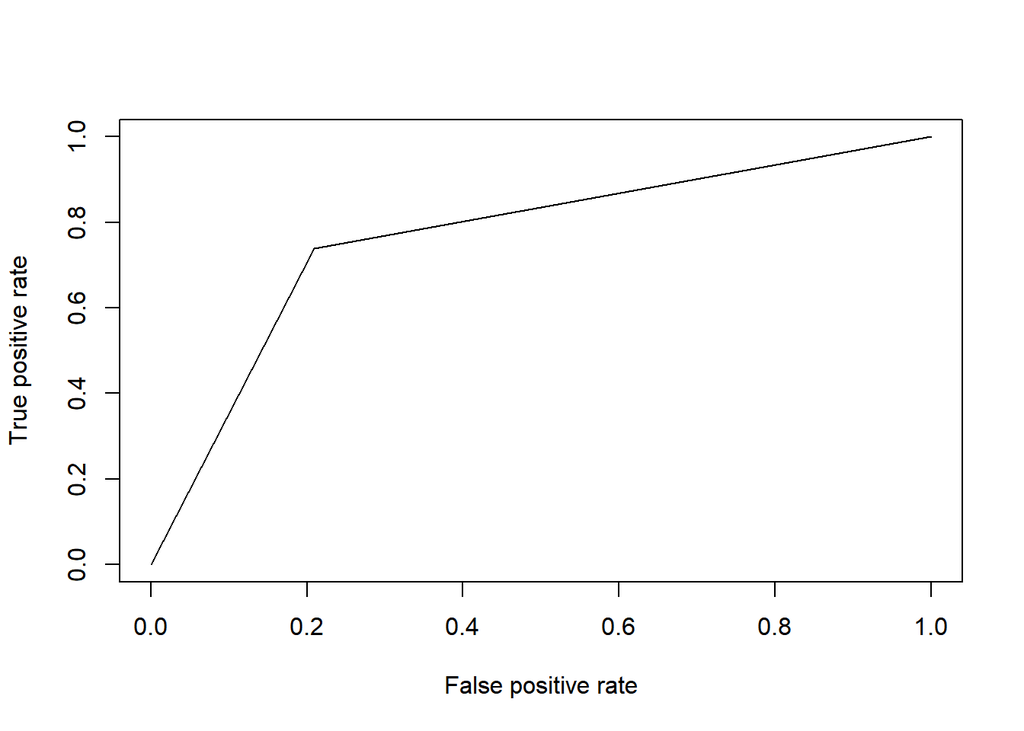

```r
pred_test1 <- prediction(pred_roc1[,2], spam_test$yesno)
ROC2 <- performance(pred_test1, "tpr", "fpr")
plot(ROC2)
```

```r
performance(pred_test1,"auc")@y.values
```

```
## [[1]]
## [1] 0.7651279
```

Bonus 1 (1 pt.)

Bring an example of a data set that cannot be partitioned effectively by a DT algorithm using test conditions involving only a single attribute. How can you overcome this difficulty?

Bonus 2 (1 pt.)

How to calculate the out-of-bag error rate. What is the difference between out-of-bag error and test error in Random Forest?